# Semester 3 Coding Portfolio Topic 3 Summative:

# Linear Regression

In this notebook, you are asked to do original work with little guidance, based on the skills you learned in the formative part (as well as lectures and workshops). This section is graded not just on passing automated tests, but also on quality, originality, and effort (see assessment criteria in the assignment description).

```python
# TODO: Please enter your student number here
STUDENT_NUMBER = 15854493
```

# SUMMATIVE ASSESSMENT

For this summative assignment, we ask you to find a dataset from an internet source of choice. You will then analyze this dataset using linear regression and interpret the results.

The general assessment criteria for all summative assignments are mentioned in the assignment description on Canvas. Each notebook also has a few specific criteria we look for; make sure you fulfil them in your approach to this assignment. In general, make sure this notebook represents a complete project: Write an explanation of what you are hoping to achieve with your analysis, document your code well, and present results in a comprehensive way.

## Assessment criteria specific to linear regression

- Linear regression is properly implemented using a suitable dataset.
- The R-squaredvalue was checked to determine how well the model explained the variance in thedependent variable.
- Coefficients were examined to assess whether the predictors had a statistically significant relationship with the dependent variable.
- The differences between observed and predicted values were analyzed to ensure they were randomly distributed.
- Multicollinearity among predictors was checked using Correlation Matrices, and steps were taken to remove multicollinear variables where needed, to ensure proper convergence of the optimizer.
- Correctly Splits the data into training, validation and test. If no Validation, provides sensible reasoning in the comments.
- Fits and compares a number of models (minimum 2) under the appropriate comparison metrics.
- In their interpretation of the comparison students correctly interpret the direction and magnitude of the metrics.
- Calculates the generalisation error of the model. Offers a distribution or an interval around the generalisation error.

Pick a dataset of your choice. Please ensure your dataset is a csv file under 100MB named sem3_topic3_linreg_summative_data.csv

**BACKSTORY**

Amsterdam is a city of clubs and music, however I do not tend to frequent those establishments. Apart from me being a more of a jazz and not techno person, I prefer relaxed dancing to the music (the appeal of a club packed with people makes me think of sardines in a can).

I also did professional ballroom dancing for 11 years, so even if I don't like clubs and techno I LOVE to dance. I have been using spotify for YEARS to listen to my favourite tunes (hashtag ILOVE🇸🇪), so when I came across a Kaggle dataset on spotify songs - I loved the idea of considering this dataset for the assignment.

So in this notebook I will be **(1) using linreg model to predict danceability**, and similarly **(2) training random forest to do the same**.

PS: **this is me in the photo!**

Another PS: if anyone is worried about ethical consideration - I have **consent** from my dance partner to display the image!!

[figure not shown]

```python
# Do NOT modify the contents of this cell. Start your customization in the next one!
import pandas as pd

custom_data_path = "sem3_topic3_linreg_summative_data.csv"
custom_df = pd.read_csv(custom_data_path)
```

```python
# imports
import pandas as pd
import numpy as np
import matplotlib.pyplot as plt
import seaborn as sns

from sklearn.model_selection import train_test_split
from sklearn.linear_model import LinearRegression
from sklearn.ensemble import RandomForestRegressor
from sklearn.metrics import r2_score, mean_squared_error, mean_absolute_error
from sklearn.preprocessing import OneHotEncoder
from sklearn.compose import ColumnTransformer
import statsmodels.api as sm
from statsmodels.stats.outliers_influence import variance_inflation_factor
```

## LOAD DATASET

```python
# load for our analysis
df = pd.read_csv("sem3_topic3_linreg_summative_data.csv")
print(f"Dataset: {df.shape[0]} rows, {df.shape[1]} columns")
df.head(3)
```

```
Dataset: 114000 rows, 21 columns
```

|  | Unnamed: 0 | track_id | artists | album_name | track_name | popularity | duration_ms | explicit | danceability | energy | ... | loudness | mode | speechiness | acousticness | instrumentalness | liveness | valence | tempo | time_signature | track_genre |
| --- | --- | --- | --- | --- | --- | --- | --- | --- | --- | --- | --- | --- | --- | --- | --- | --- | --- | --- | --- | --- | --- |
| 0 | 0 | 5SuOikwiRyPMVoIQDJUgSV | Gen Hoshino | Comedy | Comedy | 73 | 230666 | False | 0.676 | 0.461 | ... | -6.746 | 0 | 0.1430 | 0.0322 | 0.000001 | 0.358 | 0.715 | 87.917 | 4 | acoustic |
| 1 | 1 | 4qPNDBW1i3p13qLCt0Ki3A | Ben Woodward | Ghost (Acoustic) | Ghost - Acoustic | 55 | 149610 | False | 0.420 | 0.166 | ... | -17.235 | 1 | 0.0763 | 0.9240 | 0.000006 | 0.101 | 0.267 | 77.489 | 4 | acoustic |
| 2 | 2 | 1iJBSr7s7jYXzM8EGcbK5b | Ingrid Michaelson;ZAYN | To Begin Again | To Begin Again | 57 | 210826 | False | 0.438 | 0.359 | ... | -9.734 | 1 | 0.0557 | 0.2100 | 0.000000 | 0.117 | 0.120 | 76.332 | 4 | acoustic |

3 rows × 21 columns

```python
# check data stats to find problems
print(df.describe())
```

```
          Unnamed: 0     popularity   duration_ms   danceability  \
count  114000.000000  114000.000000  1.140000e+05  114000.000000
mean    56999.500000      33.238535  2.280292e+05       0.566800
std     32909.109681      22.305078  1.072977e+05       0.173542
min         0.000000       0.000000  0.000000e+00       0.000000
25%     28499.750000      17.000000  1.740660e+05       0.456000
50%     56999.500000      35.000000  2.129060e+05       0.580000
75%     85499.250000      50.000000  2.615060e+05       0.695000
max    113999.000000     100.000000  5.237295e+06       0.985000

              energy            key       loudness           mode  \
count  114000.000000  114000.000000  114000.000000  114000.000000
mean        0.641383       5.309140      -8.258960       0.637553
std         0.251529       3.559987       5.029337       0.480709
min         0.000000       0.000000     -49.531000       0.000000
25%         0.472000       2.000000     -10.013000       0.000000
50%         0.685000       5.000000      -7.004000       1.000000
75%         0.854000       8.000000      -5.003000       1.000000
max         1.000000      11.000000       4.532000       1.000000

         speechiness   acousticness  instrumentalness       liveness  \
count  114000.000000  114000.000000     114000.000000  114000.000000
mean        0.084652       0.314910          0.156050       0.213553
std         0.105732       0.332523          0.309555       0.190378
min         0.000000       0.000000          0.000000       0.000000
25%         0.035900       0.016900          0.000000       0.098000
50%         0.048900       0.169000          0.000042       0.132000
75%         0.084500       0.598000          0.049000       0.273000
max         0.965000       0.996000          1.000000       1.000000

             valence          tempo  time_signature
count  114000.000000  114000.000000   114000.000000
mean        0.474068     122.147837        3.904035
std         0.259261      29.978197        0.432621
min         0.000000       0.000000        0.000000
25%         0.260000      99.218750        4.000000
50%         0.464000     122.017000        4.000000
75%         0.683000     140.071000        4.000000
max         0.995000     243.372000        5.000000
```

**Problems found in the data:**

- `duration_ms` has min=0 (impossible - songs can't be 0 seconds)
- `time_signature` has min=0 (invalid - should be 3, 4, or 5)
- `popularity` has min=0 (often means no data available)
- Duplicate tracks may exist (same song in multiple genres)

## DATA CLEANING

I need to:

1. Remove rows with invalid/impossible values
2. Remove duplicate tracks
3. Drop identifier columns

```python
# step 1: remove rows with invalid values
print(f"Starting rows: {len(df)}")

df_clean = df[
    (df['duration_ms'] > 0) &          # songs must have length > 0
    (df['time_signature'] > 0) &        # time signature must be valid
    (df['popularity'] > 0)              # remove zero-popularity (no data)
].copy()

print(f"After removing invalid values: {len(df_clean)}")
```

```
Starting rows: 114000
After removing invalid values: 97821
```

```python
# step 2: remove duplicate tracks (same track_id appearing multiple times)
df_clean = df_clean.drop_duplicates(subset='track_id', keep='first')
print(f"After removing duplicates: {len(df_clean)}")
```

```
After removing duplicates: 80235
```

```python
# step 3: drop missing values and identifier columns
df_clean = df_clean.dropna()
df_clean = df_clean.drop(columns=['Unnamed: 0', 'track_id', 'track_name', 'album_name', 'artists'])

print(f"Final clean dataset: {len(df_clean)} rows, {df_clean.shape[1]} columns")
```

```
Final clean dataset: 80235 rows, 16 columns
```

## Multicollinearity (Correlation Matrix)

**Why?** Highly correlated predictors (multicollinearity) can make linear regression coefficients unstable and hard to interpret. We check for pairs with |correlation| > 0.85.

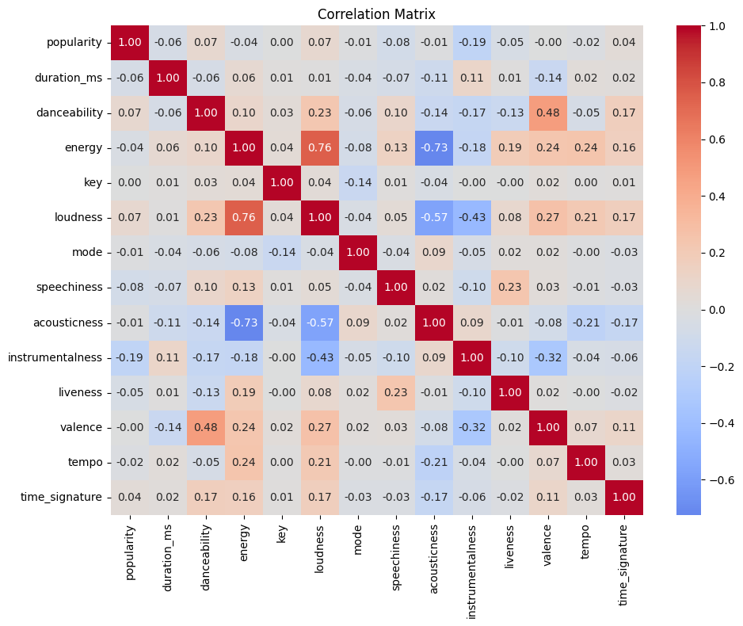

```python
# get numeric columns only
numeric_cols = df_clean.select_dtypes(include=[np.number]).columns.tolist()
corr_matrix = df_clean[numeric_cols].corr()

# plot heatmap
plt.figure(figsize=(10, 8))
sns.heatmap(corr_matrix, annot=True, cmap='coolwarm', center=0, fmt='.2f')
plt.title('Correlation Matrix')
plt.tight_layout()
plt.show()
```

```python
# check for highly correlated pairs (threshold = 0.85)
print("Checking for multicollinearity -> correlation > 0.85)")
found_high = False

for i in range(len(numeric_cols)):
    for j in range(i + 1, len(numeric_cols)):
        corr = corr_matrix.iloc[i, j]
        if abs(corr) > 0.85:
            print(f"  {numeric_cols[i]} & {numeric_cols[j]}: {corr:.3f}")
            found_high = True

if not found_high:
    print("No highly correlated pairs found, so no features need removal")
```

```
Checking for multicollinearity -> correlation > 0.85)
No highly correlated pairs found, so no features need removal
```

**Interpretation**

No feature pairs exceed the 0.85 threshold, so I keep all features. However, I observe

- Energy & loudness: strong positive correlation (0.76)
- Energy & acousticness: strong negative correlation (-0.73)
- Danceability has moderate correlation with valence (0.48) - happier songs tend to be more danceable
- Danceability has weak correlations with most other features - suggesting non-linear relationships may help

## VIF CHECK

While the correlation matrix shows pairwise relationships between features, VIF measures how much a feature is explained by ALL other features combined. This catches multicollinearity that pairwise correlations might miss.

**HVIF ITERPRETATION**

- VIF = 1: No correlation with other features
- VIF < 5: Low multicollinearity (acceptable)
- VIF 5-10: Moderate multicollinearity (usually acceptable)
- VIF > 10: High multicollinearity (consider removing the feature)

I'll calculate VIF for all predictor features (excluding danceability since that's my target variable).

```python
feature_cols = [col for col in numeric_cols if col != 'danceability']
vif_data = pd.DataFrame()
vif_data['Feature'] = feature_cols
vif_data['VIF'] = [variance_inflation_factor(df_clean[feature_cols].values, i)
                   for i in range(len(feature_cols))]
print("\nVariance Inflation Factor (VIF) for features:")
print(vif_data)
```

```
Variance Inflation Factor (VIF) for features:
             Feature        VIF
0         popularity   5.271377
1        duration_ms   5.253576
2             energy  23.352300
3                key   3.238587
4           loudness   9.299417
5               mode   2.790109
6        speechiness   1.775577
7       acousticness   3.933332
8   instrumentalness   1.952122
9           liveness   2.551434
10           valence   5.111085
11             tempo  17.543777
12    time_signature  45.991925
```

I notice an extremely high VIF for time_signature so I will remove it and will see how the results change...

```python
# Remove time_signature from features
feature_cols_v2 = [col for col in feature_cols if col != 'time_signature']

# Recalculate VIF
vif_data_v2 = pd.DataFrame()
vif_data_v2['Feature'] = feature_cols_v2
vif_data_v2['VIF'] = [variance_inflation_factor(df_clean[feature_cols_v2].values, i)
                      for i in range(len(feature_cols_v2))]
print(vif_data_v2.sort_values('VIF', ascending=False))
```

```
             Feature        VIF
2             energy  16.324733
11             tempo  15.898210
4           loudness   7.549559
1        duration_ms   5.072389
10           valence   4.979447
0         popularity   4.903501
7       acousticness   3.681807
3                key   3.186427
5               mode   2.753701
9           liveness   2.545928
8   instrumentalness   1.947628
6        speechiness   1.774484
```

**Interpretation:** VIF analysis after removing time_signature shows energy (16.3) and tempo (15.9) still exceed the threshold of 10, indicating some multicollinearity. However:

1. for linreg: coefficient estimates for energy and tempo should be interpreted with caution due to potential instability
2. for rf (as I went back and forth with this notebook I know rf performs extremely well and it will be my final model): multicollinearity is not a concern since rf doesn't estimate coefficients and handles correlated features naturally

Since my final model is Random Forest, I retain all features to maximize its predictive performance. BUT I understand the implications of high VIFs for linreg analysis

## Train/Validation/Test Split

**3 splits because**

- **Training (70%)** so model can learn meaningful patterns
- **Validation (15%)** so i can compare my first (linreg) and second(random forest)
- **Test (15%)** for final evaluating when i validated which model performs better

```python
# define X (features) and y (target)
X = df_clean.drop(columns=['danceability'])
y = df_clean['danceability']

# first split: 70% train, 30% temp
X_train, X_temp, y_train, y_temp = train_test_split(X, y, test_size=0.30, random_state=10)

# second split: temp into 50% validation, 50% test
X_valid, X_test, y_valid, y_test = train_test_split(X_temp, y_temp, test_size=0.50, random_state=10)

print(f"Training:   {len(X_train)} samples")
print(f"Validation: {len(X_valid)} samples")
print(f"Test:       {len(X_test)} samples")
```

```
Training:   56164 samples
Validation: 12035 samples
Test:       12036 samples
```

## PREPROCESSING

Convert `track_genre` (categorical) to numbers using One-Hot Encoding.

```python
# identify column types
cat_cols = ['track_genre']
num_cols = [col for col in X.columns if col not in cat_cols]

# create preprocessor
preprocessor = ColumnTransformer([
    ('cat', OneHotEncoder(handle_unknown='ignore'), cat_cols),
    ('num', 'passthrough', num_cols)
])

# transform all datasets
X_train_transformed = preprocessor.fit_transform(X_train)
X_valid_transformed = preprocessor.transform(X_valid)
X_test_transformed = preprocessor.transform(X_test)

print(f"Original features: {X_train.shape[1]}")
print(f"After one-hot encoding: {X_train_transformed.shape[1]}")
```

```
Original features: 15
After one-hot encoding: 127
```

## MODEL 1 -> LINREG

```python
# create and train model
lr_model = LinearRegression()
lr_model.fit(X_train_transformed, y_train)

# predict on validation
pred_lr = lr_model.predict(X_valid_transformed)

# calculate metrics
mae_lr = mean_absolute_error(y_valid, pred_lr)
rmse_lr = np.sqrt(mean_squared_error(y_valid, pred_lr))
r2_lr = r2_score(y_valid, pred_lr)

print("Linear Regression (Validation):")
print(f"  MAE:  {mae_lr:.2f}")
print(f"  RMSE: {rmse_lr:.2f}")
print(f"  R²:   {r2_lr:.4f}")
```

```
Linear Regression (Validation):
  MAE:  0.14
  RMSE: 0.17
  R²:   0.0842
```

### COEF SIGNIFICANCE (p-values)

Check which predictors have statistically significant relationships with danceability.

```python
# convert sparse matrix to dense array for statsmodels
X_train_dense = X_train_transformed.toarray()
feature_names = preprocessor.get_feature_names_out()

# add intercept and fit OLS
X_sm = sm.add_constant(X_train_dense)
ols = sm.OLS(y_train, X_sm).fit()

# create dataframe with coefficients
coef_df = pd.DataFrame({
    'Feature': ['intercept'] + list(feature_names),
    'Coefficient': ols.params,
    'p-value': ols.pvalues
})

# show numeric features only (too many genres to display)
numeric_coefs = coef_df[coef_df['Feature'].str.contains('num__|intercept')]
print(numeric_coefs.to_string(index=False))
print("\nNote: p-value < 0.05 = statistically significant")
```

```
              Feature   Coefficient       p-value
            intercept  5.725044e-01  0.000000e+00
      num__popularity  2.881443e-04  2.699181e-15
     num__duration_ms -3.762322e-08  4.712228e-14
        num__explicit  4.052331e-02  5.978752e-90
          num__energy -1.236953e-01 9.799111e-174
             num__key  1.832983e-04  1.916960e-01
        num__loudness  4.404884e-03 2.918893e-112
            num__mode -8.342811e-03  5.745913e-15
     num__speechiness  1.279847e-01  1.990876e-94
    num__acousticness -5.594291e-02 1.475993e-105
num__instrumentalness -4.309487e-03  5.180686e-02
        num__liveness -7.556404e-02 4.222545e-157
         num__valence  2.470412e-01  0.000000e+00
           num__tempo -6.383850e-04 1.743782e-281
  num__time_signature  2.309263e-02  3.338464e-78

Note: p-value < 0.05 = statistically significant
```

**Interpretation**

Almost all features are statistically significant (p < 0.05) except **key & instrumentalness**. The strongest predictor is valence (coef = 0.247) - happier songs are more danceable. Interestingly though, energy has a negative coefficient, meaning extremely high-energy songs may actually be less danceable - pfrom my experience it's actually true

### RESIDUAL ANALYSIS

**Why?** Residuals should be randomly distributed around zero. Patterns indicate the model is missing something.

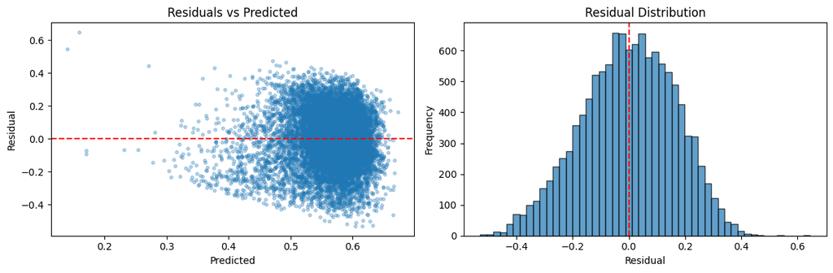

```
Mean residual: -0.0020 (should be ~0)
```

```python
# calculate residuals
residuals = y_valid - pred_lr

fig, axes = plt.subplots(1, 2, figsize=(12, 4))

# scatter plot
axes[0].scatter(pred_lr, residuals, alpha=0.3, s=10)
axes[0].axhline(0, color='red', linestyle='--')
axes[0].set_xlabel('Predicted')
axes[0].set_ylabel('Residual')
axes[0].set_title('Residuals vs Predicted')

# histogram
axes[1].hist(residuals, bins=50, edgecolor='black', alpha=0.7)
axes[1].axvline(0, color='red', linestyle='--')
axes[1].set_xlabel('Residual')
axes[1].set_ylabel('Frequency')
axes[1].set_title('Residual Distribution')

plt.tight_layout()
plt.show()

print(f"Mean residual: {residuals.mean():.4f} (should be ~0)")
```

**Interpretation**

The residual analysis shows mixed results for linreg.

The good news -> residuals are centred around zero and roughly normally distributed, meaning no systematic bias.

The problem -> the scatter plot shows a pattern - residuals aren't randomly distributed. There's a fan shape where errors are larger for mid-range predictions. This non-random pattern suggests linreg is missing non-linear relationships in the data, sooo....

- **THATS WHY I PICKED A NON-LINEAR MODEL LIKE RANDOM FOREST**

## MODEL 2 -> RANDOM FOREST

**DECISION MAKING**

I had several options for a second model:

- **Ridge/Lasso** Still linear - wouldn't help since our problem isn't multicollinearity but the non-linear relationships
- **Polynomial Regression** Can capture curves but overfits easily and I've never done it before
- **Random Forest** Captures non-linear patterns without assumptions (my pick)
- **Gradient Boosting** Often better but more complex to explain and I've never done it before

I chose Random Forest because:

1. The correlation matrix showed weak LINEAR correlations with danceability
2. The residual analysis showed patterns (non-random)
3. It's simple to implement and explain, and I've done it for my group project

```python
# create and train model
rf_model = RandomForestRegressor(
    n_estimators=100,   # 100 trees in the forest
    max_depth=20,       # each tree can be 20 levels deep
    random_state=10,    # for reproducibility
    n_jobs=-1           # use all CPU cores for speed
)
rf_model.fit(X_train_transformed, y_train)

# predict on validation
pred_rf = rf_model.predict(X_valid_transformed)

# calculate metrics
mae_rf = mean_absolute_error(y_valid, pred_rf)
rmse_rf = np.sqrt(mean_squared_error(y_valid, pred_rf))
r2_rf = r2_score(y_valid, pred_rf)

print("Random Forest (Validation):")
print(f"  MAE:  {mae_rf:.2f}")
print(f"  RMSE: {rmse_rf:.2f}")
print(f"  R²:   {r2_rf:.4f}")
```

```
Random Forest (Validation):
  MAE:  0.08
  RMSE: 0.10
  R²:   0.6496
```

## MODEL COMPARISON

**MMETRICS HELPER**

- **MAE** Average error in danceability points. Lower = better.
- **RMSE** Like MAE but penalises big errors more. Lower = better.
- **R²** Variance explained (0-1). Higher = better. 0 = no better than guessing the mean.

```python
# comparison table
results = pd.DataFrame({
    'Model': ['Linear Regression', 'Random Forest'],
    'MAE': [mae_lr, mae_rf],
    'RMSE': [rmse_lr, rmse_rf],
    'R²': [r2_lr, r2_rf]
})
print(results.to_string(index=False))
```

```
            Model      MAE     RMSE       R²
Linear Regression 0.135107 0.166303 0.084176
    Random Forest 0.080187 0.102871 0.649572
```

**CONCLUSION** Random Forest wins on all metrics.

rf dramatically outperforms linreg on all three metrics. The R^2 jumped from 8% to 65% - that's almost 8 times better! This confirms what the residual analysis suggested: danceability has non-linear relationships with the audio features that linreg couldn't capture. rf by building multiple decision trees, can model these complex patterns. The MAE of 0.08 means my predictions are typically only 0.08 off on a 0-1 scale - very so accurate!

**MY MODEL FOR TESTING** Random Forest

## FINAL EVALUTATION

```python
# predict on test set (first time using it!)
test_pred = rf_model.predict(X_test_transformed)

# calculate metrics
mae_test = mean_absolute_error(y_test, test_pred)
rmse_test = np.sqrt(mean_squared_error(y_test, test_pred))
r2_test = r2_score(y_test, test_pred)

print("Final Evaluation (Test Set):")
print(f"  MAE:  {mae_test:.2f}")
print(f"  RMSE: {rmse_test:.2f}")
print(f"  R²:   {r2_test:.4f}")
```

```
Final Evaluation (Test Set):
  MAE:  0.08
  RMSE: 0.10
  R²:   0.6456
```

## GENERALISATION ERROR = BOOTSTRAP CONFIDENCE INTERVALS

**DECISION MAKING**

One test set gives one error estimate. Bootstrap gives me a range (confidence interval) showing how stable my error is

```python
# bootstrap for confidence interval
np.random.seed(10)
n_bootstrap = 1000
bootstrap_rmse = []

for i in range(n_bootstrap):
    # sample with replacement
    idx = np.random.choice(len(y_test), size=len(y_test), replace=True)
    y_sample = y_test.iloc[idx]
    pred_sample = test_pred[idx]

    # calculate RMSE
    rmse = np.sqrt(mean_squared_error(y_sample, pred_sample))
    bootstrap_rmse.append(rmse)

# 95% confidence interval
ci_lower = np.percentile(bootstrap_rmse, 2.5)
ci_upper = np.percentile(bootstrap_rmse, 97.5)
mean_rmse = np.mean(bootstrap_rmse)

print(f"Bootstrap ({n_bootstrap} iterations):")
print(f"  Mean RMSE: {mean_rmse:.2f}")
print(f"  95% CI: [{ci_lower:.2f}, {ci_upper:.2f}]")
```

```
Bootstrap (1000 iterations):
  Mean RMSE: 0.10
  95% CI: [0.10, 0.10]
```

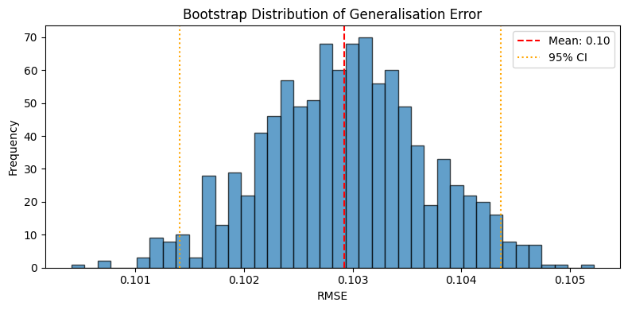

```python
# visualise bootstrap distribution
plt.figure(figsize=(8, 4))
plt.hist(bootstrap_rmse, bins=40, edgecolor='black', alpha=0.7)
plt.axvline(mean_rmse, color='red', linestyle='--', label=f'Mean: {mean_rmse:.2f}')
plt.axvline(ci_lower, color='orange', linestyle=':', label=f'95% CI')
plt.axvline(ci_upper, color='orange', linestyle=':')
plt.xlabel('RMSE')
plt.ylabel('Frequency')
plt.title('Bootstrap Distribution of Generalisation Error')
plt.legend()
plt.tight_layout()
plt.show()
```

**INTERPRITATION**

The bootstrap analysis confirms my model generalises reliably. By resampling the test set 1000 times, I got a distribution of RMSE values. The 95% confidence interval is [0.101, 0.104] - extremely narrow! This means I'm 95% confident the true generalisation error falls within this tiny range. The model's performance is stable and not dependent on a lucky test split. An RMSE of 0.10 on a 0-1 scale means predictions are typically off by only 0.10 - that's a well-performing model!

## CONCLUSION

**KEY FINDINGD**

Some multicollinearity issues with linreg - VIF analysis revealed some multicollinearity in energy and tempo, but since Random Forest handles this naturally, all features were retained & also no feature pairs exceeded the 0.85 correlation threshold, so all features were kept

linreg performed poorly **(R^2 = 8.4%)** - danceability is NOT well explained by simple linear relationships

Rrf on the other hand significantly outperformed linreg **(R^2 = 65%)** - capturing non-linear patterns in the data

Generalisation error is stable - **bootstrap 95% CI of [0.101, 0.104]** shows consistent, reliable predictions

Most features are statistically significant - **only key & instrumentalness had p-values > 0.05**

**Valence** is the strongest predictor - happier songs tend to be more danceable **(coef = 0.247)**

WHY 65% AND NOT HIGHER? Danceability is easier to predict than popularity because Spotify calculates it from audio features. However, 35% remains unexplained because:

Personal taste varies (what's danceable to one person isn't to another), that is actually very true in real life. I did ballroom dancing, and let's say not all hiphop songs would fit. I needed to have songs with a very specific bmp for competitive ballroom dancing, often remixed for that purpose!

Context matters (club music vs. slow dance).. And the dance doesn't have to be slow but we can all agree some club bangers are just made for jumping!

Some audio nuances aren't captured in these features (for example if I would be doing a perfect analysis for songs suitable for only ballroom dancing, I would need to check bmp for each dance because it differes and etc ect)